# Root Fungi Analysis

Wes Bickford

4/26/2017

# Root Fungi Analysis

## Hyphal Colonization

```
##                                Df  Sum Sq Mean Sq F value   Pr(>F)
## percol15$Site                   7 0.25122 0.03589   6.407 6.29e-05 ***
## percol15$Lineage                1 0.17636 0.17636  31.484 2.30e-06 ***
## percol15$Site:percol15$Lineage  7 0.07532 0.01076   1.921   0.0947 .
## Residuals                      36 0.20165 0.00560
## ---
## Signif. codes:  0 '***' 0.001 '**' 0.01 '*' 0.05 '.' 0.1 ' ' 1
```

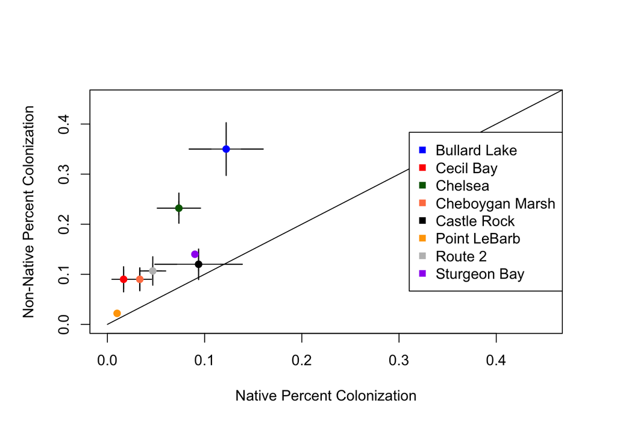

## Nutrients ### Soil Nutrients

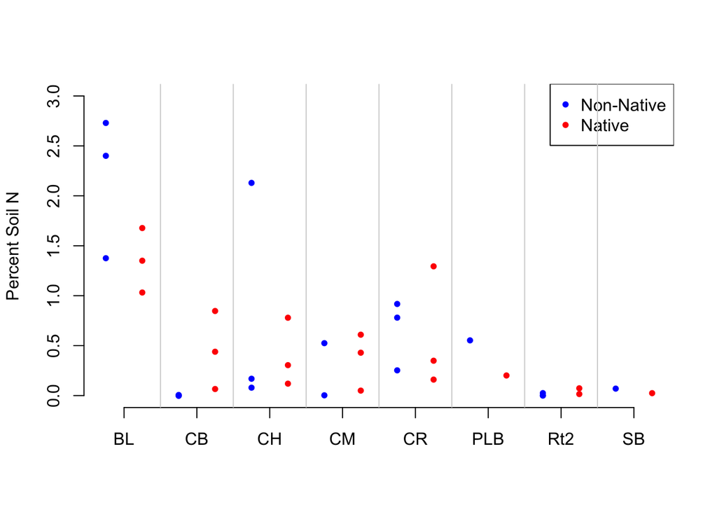

Sites differed wrt to Soil N but not markedly

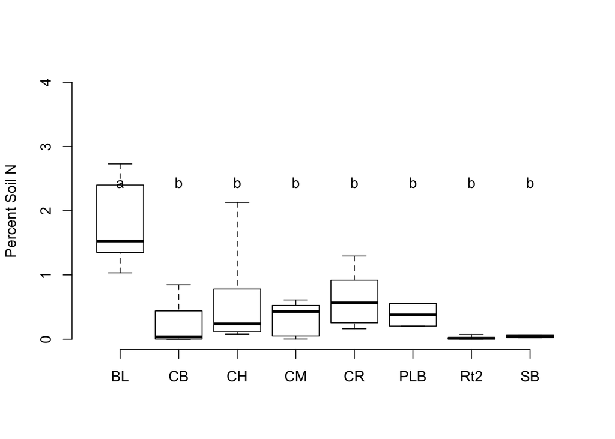

```
##             Df Sum Sq Mean Sq F value   Pr(>F)
## Site         7 11.665  1.6664    6.75 8.72e-05 ***
## Lineage      1  0.165  0.1654    0.67     0.42
## Residuals   29  7.159  0.2469
## ---
## Signif. codes:  0 '***' 0.001 '**' 0.01 '*' 0.05 '.' 0.1 ' ' 1
```

```
##   Tukey multiple comparisons of means
##     95% family-wise confidence level
##
## Fit: aov(formula = SoilN ~ Site + Lineage, data = meta_finite)
##
## $Site
##                diff        lwr         upr     p adj
## CB-BL   -1.53485917 -2.4704881 -0.59923021 0.0002306
## CH-BL   -1.16416917 -2.0997981 -0.22854021 0.0071925
## CM-BL   -1.43773133 -2.4190273 -0.45643540 0.0010803
## CR-BL   -1.13538750 -2.0710165 -0.19975854 0.0092897
## PLB-BL  -1.38389833 -2.7070775 -0.06071917 0.0354040
## Rt2-BL  -1.73803733 -2.7193333 -0.75674140 0.0000725
## SB-BL   -1.71405583 -3.0372350 -0.39087667 0.0046752
## CH-CB    0.37069000 -0.5649390  1.30631896 0.8944208
## CM-CB    0.09712783 -0.8841681  1.07842376 0.9999773
## CR-CB    0.39947167 -0.5361573  1.33510063 0.8532584
## PLB-CB   0.15096083 -1.1722183  1.47414000 0.9999404
## Rt2-CB  -0.20317817 -1.1844741  0.77811776 0.9970688
## SB-CB   -0.17919667 -1.5023758  1.14398250 0.9998118
## CM-CH   -0.27356217 -1.2548581  0.70773376 0.9827255
## CR-CH    0.02878167 -0.9068473  0.96441063 1.0000000
## PLB-CH  -0.21972917 -1.5429083  1.10345000 0.9992802
## Rt2-CH  -0.57386817 -1.5551641  0.40742776 0.5570017
## SB-CH   -0.54988667 -1.8730658  0.77329250 0.8693614
## CR-CM    0.30234383 -0.6789521  1.28363976 0.9699618
## PLB-CM   0.05383300 -1.3020222  1.40968817 1.0000000
## Rt2-CM  -0.30030600 -1.3252362  0.72462417 0.9771782
## SB-CM   -0.27632450 -1.6321797  1.07953067 0.9973441
## PLB-CR  -0.24851083 -1.5716900  1.07466833 0.9984128
## Rt2-CR  -0.60264983 -1.5839458  0.37864610 0.4970323
## SB-CR   -0.57866833 -1.9018475  0.74451083 0.8377029
## Rt2-PLB -0.35413900 -1.7099942  1.00171617 0.9881097
## SB-PLB  -0.33015750 -1.9507144  1.29039939 0.9973498
## SB-Rt2   0.02398150 -1.3318737  1.37983667 1.0000000
##
## $Lineage
##               diff        lwr       upr    p adj
## Nat-Inv -0.1312724 -0.4609625 0.1984176 0.422083
```

Sites differend in Soil N significantly, but not by lineage. The Lineage of a particular population was not driven by Soil N Additionally, only the Bullard Lake Site was significantly different from the rest

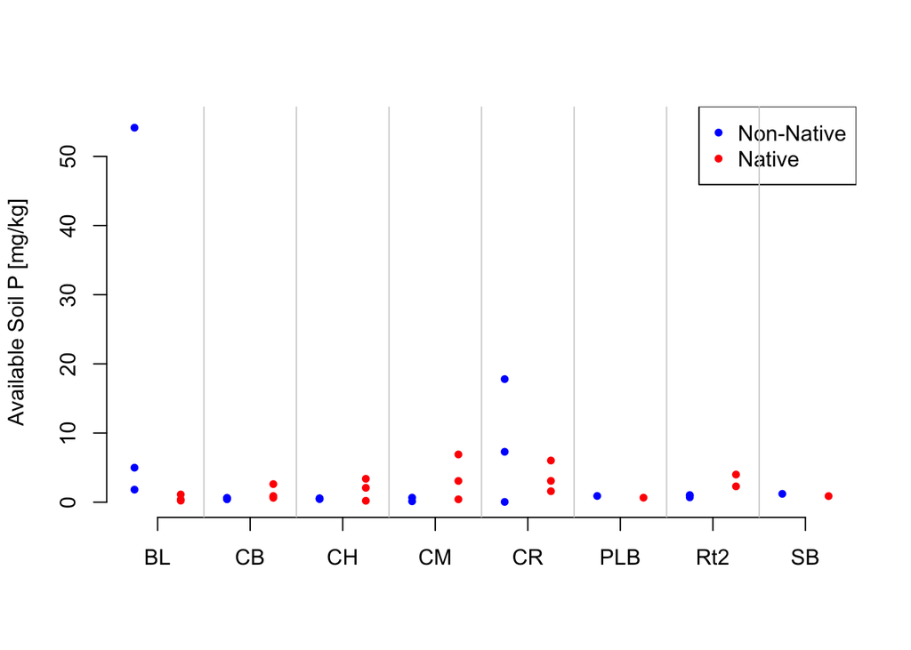

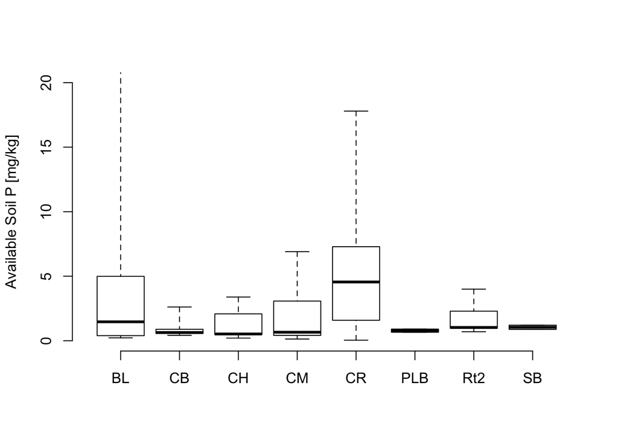

```
##             Df Sum Sq Mean Sq F value Pr(>F)
## Site         7  446.2   63.74   0.744  0.637
## Lineage      1   79.8   79.82   0.932  0.342
## Residuals   29 2483.3   85.63
```

Soil P did not differ by Site or Lineage

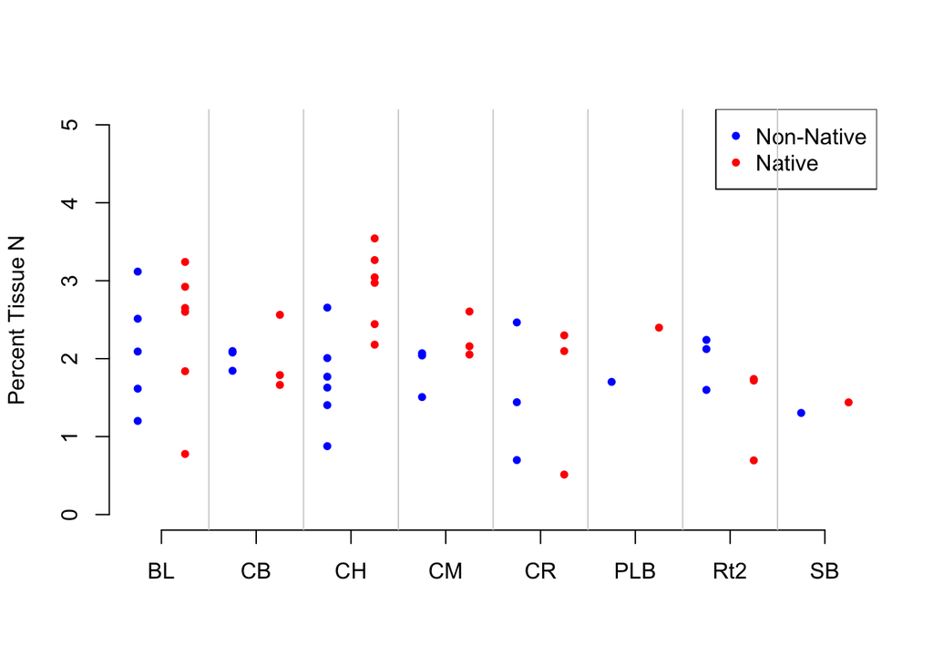

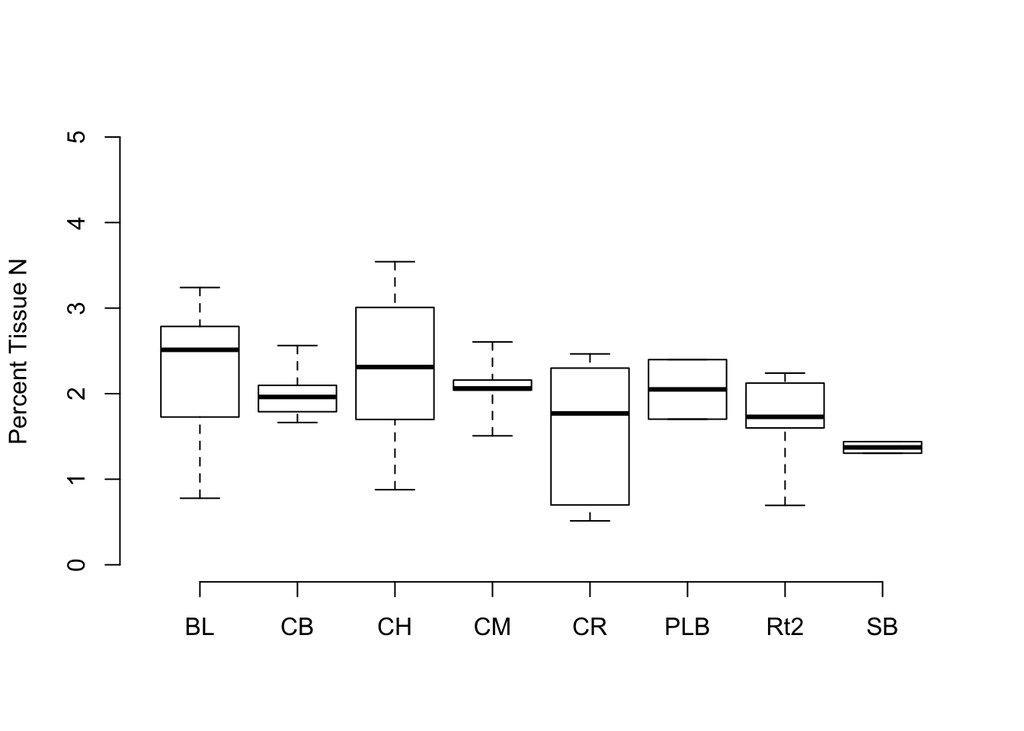

```
##             Df Sum Sq Mean Sq F value Pr(>F)
## Site         7   4.21  0.6014   1.365 0.2452
## Lineage      1   1.55  1.5503   3.519 0.0676 .
## Residuals   42  18.50  0.4406
## ---
## Signif. codes:  0 '***' 0.001 '**' 0.01 '*' 0.05 '.' 0.1 ' ' 1
```

No significant difference in Tissue N by site, but Lineage was marginally significant

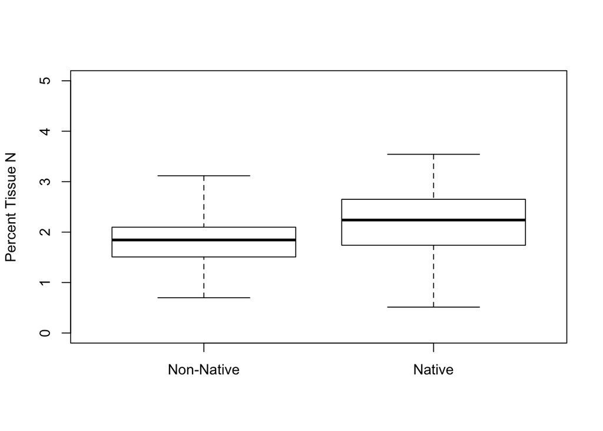

```
##
##  Kruskal-Wallis rank sum test
##
## data:  TisN by Lineage
## Kruskal-Wallis chi-squared = 4.4935, df = 1, p-value = 0.03402
```

There is a significant difference in Tissue N by Lineage (P = 0.034023) *but* Native is slightly higher than Non-native. This is unexpected given the difference in photosyntheic capacity between the two lineages

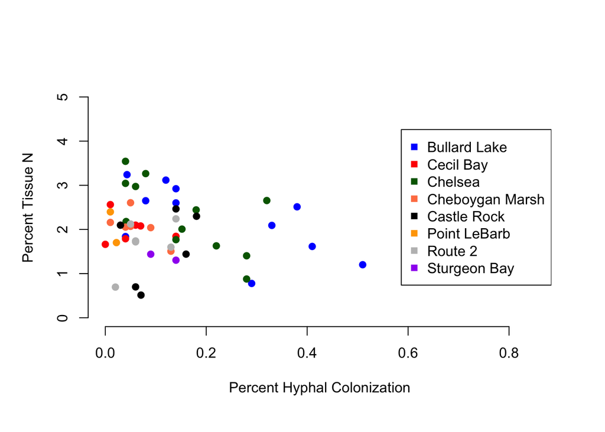

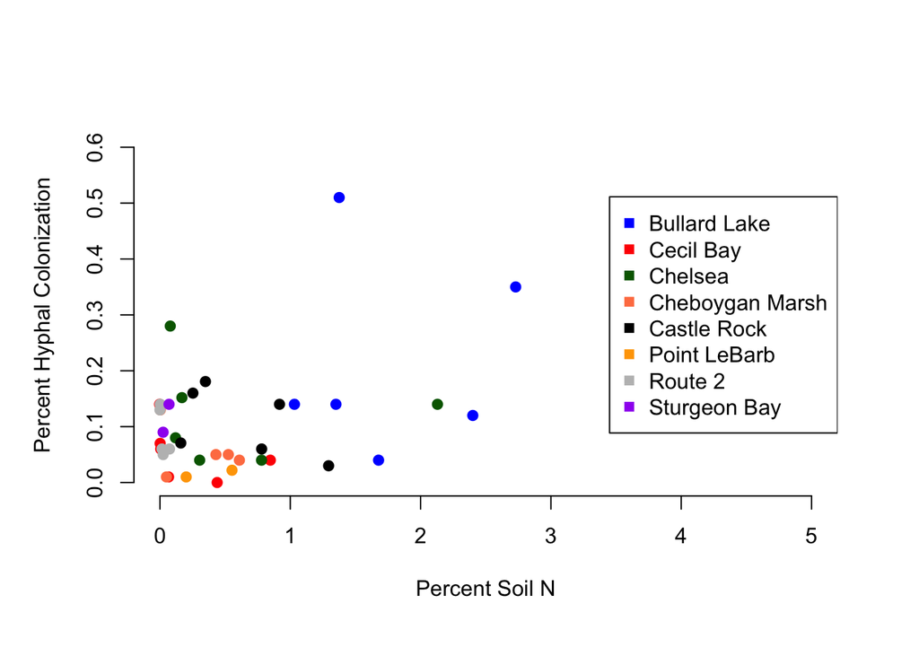

Soil N does not appear to influence Hyphal Colonization

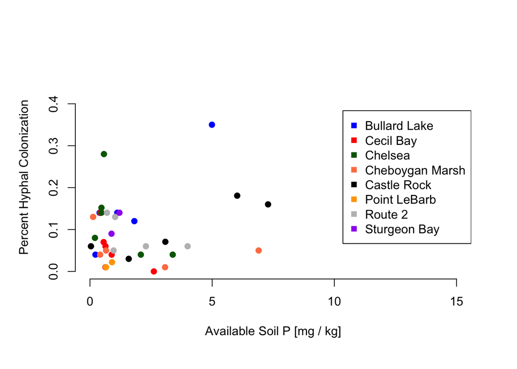

Soil P does not appear to influence hyphal colonization

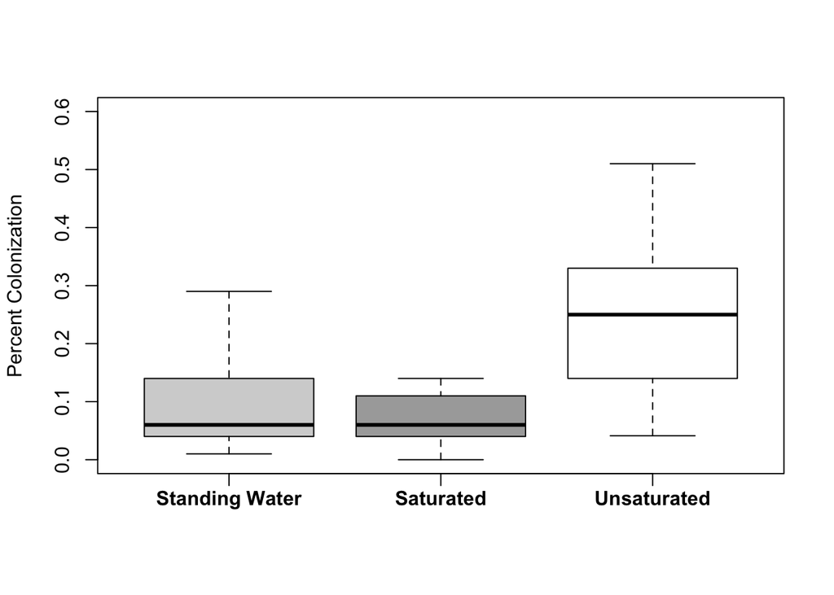

This makes a lot of sense since most fungi are aerobic

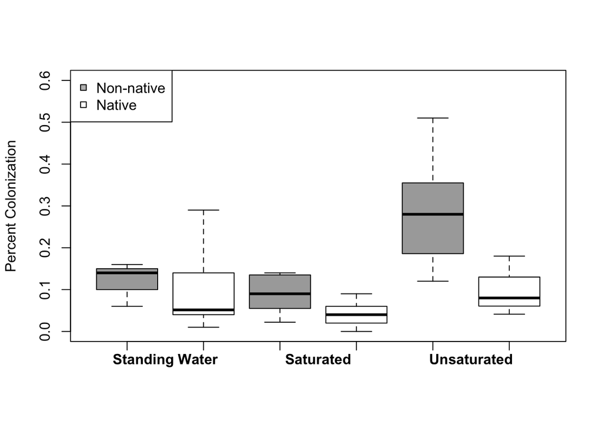

```
##                   Df  Sum Sq Mean Sq F value   Pr(>F)
## Sat_lev            2 0.28666 0.14333  23.816 8.82e-08 ***
## Lineage.x          1 0.06258 0.06258  10.398  0.00235 **
## Sat_lev:Lineage.x  2 0.03480 0.01740   2.891  0.06590 .
## Residuals         45 0.27082 0.00602
## ---
## Signif. codes:  0 '***' 0.001 '**' 0.01 '*' 0.05 '.' 0.1 ' ' 1
```

This shows that the trend towards higher colonization in Non-native persists regardless of water level differences. However the differences are most pronounced in un-saturated soils

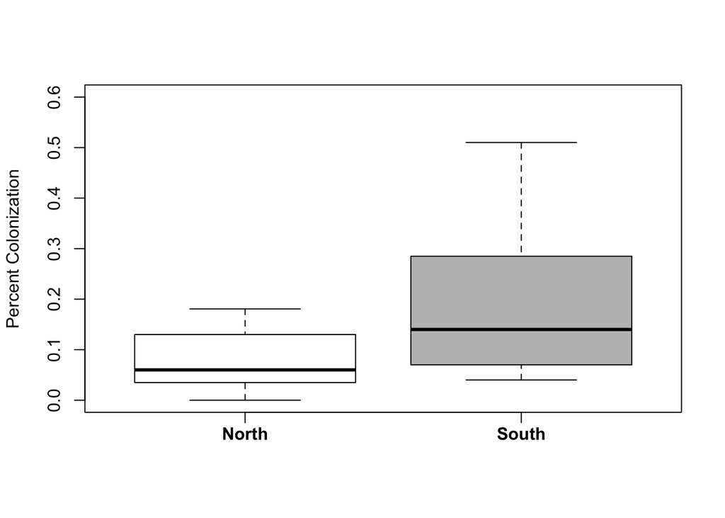

Kruskal-Wallace test confirms that colonization in North and South are significantly different from one another (P = 0.0015295)

## Rarefaction Curves

These are rarefaction curves for all samples. Samples were rarefied to 200 sequences as that was the lowest number at any site.

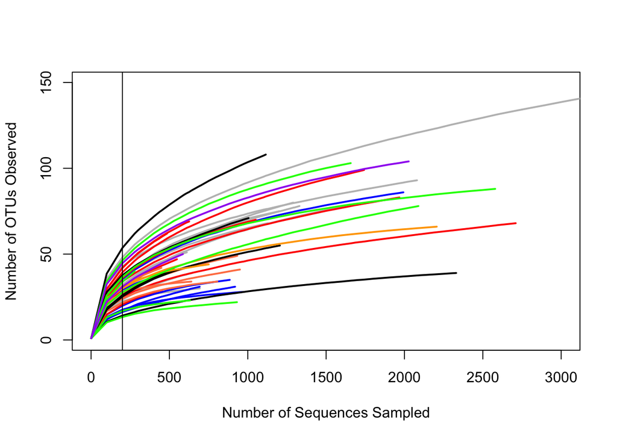

## Alpha Diversity

The following shows shannon diversity by site and lineage

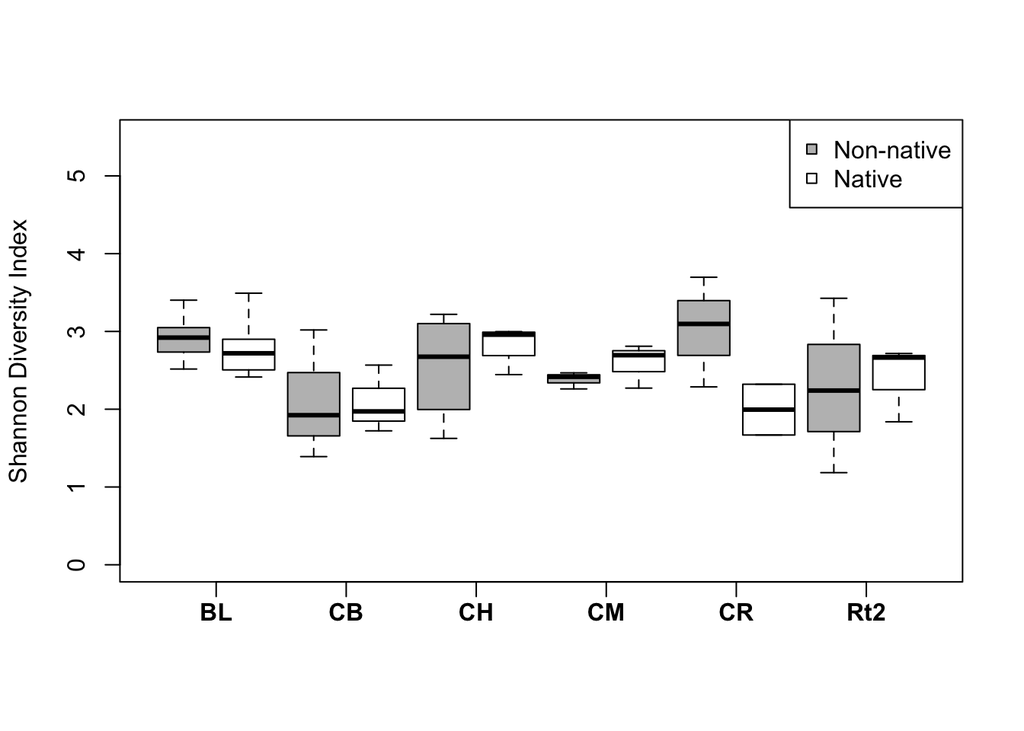

Histograms show that shannon diversity is fairly normally distributed.

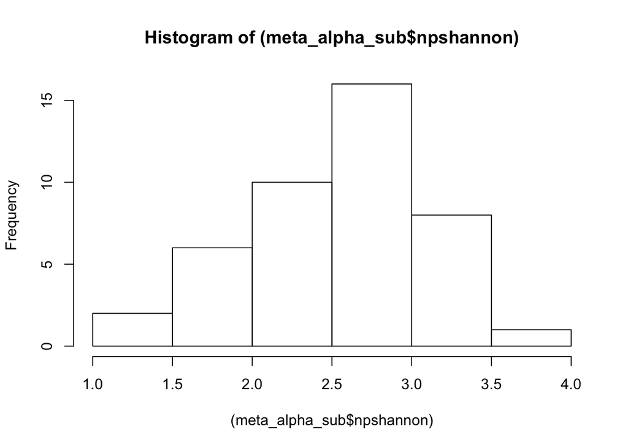

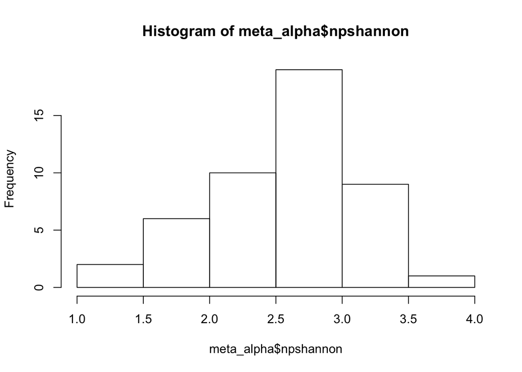

Assuming those are normally distributed, here are the results of an ANOVA by site and lineage. No significant difference in alpha diversity by site or lineage.

```
##              Df Sum Sq Mean Sq F value Pr(>F)
## Site          7  3.239  0.4627   1.567  0.182
## Lineage       1  0.014  0.0143   0.048  0.827
## Site:Lineage  7  1.647  0.2353   0.797  0.596
## Residuals    31  9.150  0.2952
```

## Community Analysis

### PerManova

The following is a PerMANOVA of phyloytpes by site and Lineage

```
##
## Call:
## adonis(formula = shared ~ Site * Lineage, data = meta_alpha,      method = "bray")
##
## Permutation: free
## Number of permutations: 999
##
## Terms added sequentially (first to last)
##
##              Df SumsOfSqs MeanSqs F.Model      R2 Pr(>F)
## Site          7    3.4949 0.49926 1.63479 0.23035  0.001 ***
## Lineage       1    0.2488 0.24885 0.81483 0.01640  0.664
## Site:Lineage  7    1.9611 0.28015 0.91733 0.12925  0.705
## Residuals    31    9.4674 0.30540         0.62400
## Total        46   15.1722                 1.00000
## ---
## Signif. codes:  0 '***' 0.001 '**' 0.01 '*' 0.05 '.' 0.1 ' ' 1
```

There is a significant *site* effect. Lineage and their interaction are non-significant.

### NMDS

The following is an NMDS (stress = 0.2548247) showing Lineage as different shapes and site by color. The ellipses are sd by site.

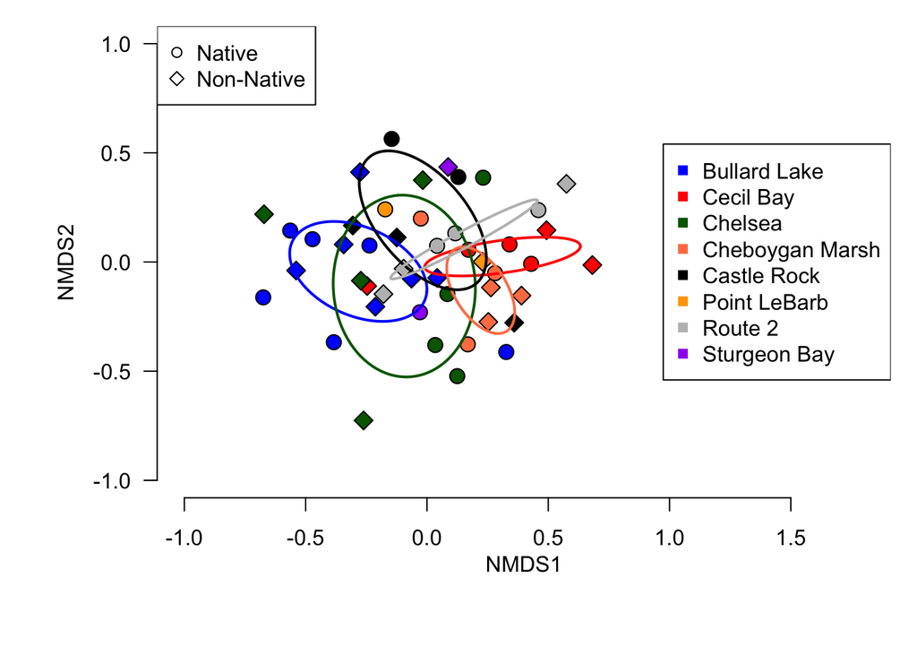

### Remove rare taxa

I removed rare taxa using relative abundance data. Any OTU that made up less than 0.1% of the total sequences was removed. This is more stringent than removing singletons, but ensures that rare taxa are not responsible for site effects. The following are results of a permanova of only abundant taxa by site and lineage.

```
##
## Call:
## adonis(formula = shared_abundant ~ Site * Lineage, data = meta_alpha)
##
## Permutation: free
## Number of permutations: 999
##
## Terms added sequentially (first to last)
##
##              Df SumsOfSqs MeanSqs F.Model      R2 Pr(>F)
## Site          7    3.4563 0.49375 1.65877 0.23310  0.001 ***
## Lineage       1    0.2419 0.24186 0.81255 0.01631  0.664
## Site:Lineage  7    1.9017 0.27167 0.91269 0.12826  0.737
## Residuals    31    9.2275 0.29766         0.62233
## Total        46   14.8274                 1.00000
## ---
## Signif. codes:  0 '***' 0.001 '**' 0.01 '*' 0.05 '.' 0.1 ' ' 1
```

Removing rare taxa reduced the total OTU number from 251 to 85

There is still a significant difference in the community using only abundant taxa.

I also performed a Kruskal-Wallace test to see if the relative abundance of any individual taxa differed by site or lineage. All tests were non-significant indicating that no individual otu relative abundances are significantly different by site or lineage

### NMDS with Rare Taxa removed

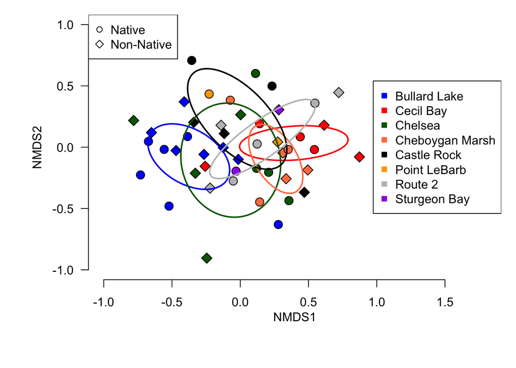

Using the abundant taxa still show differences by Site. Looks a lot messier. Removing rare taxa made the sites more similar, but still different from one another

## Taxonomic Analysis

### By Phylum

The following show all fungal Phyla by relative sequence abundance

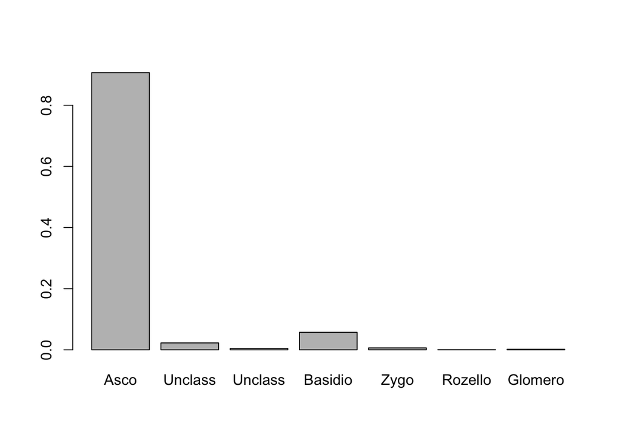

Ascomycota makes up 90.6595745% of the total sequences!

Glomeromycota makes up only 0.1914894%!!

```
##               Native    NonNative
## Asco    0.9019565217 0.9110416667
## Unclass 0.0226086957 0.0227083333
## Unclas  0.0078260870 0.0014583333
## Basidio 0.0643478261 0.0506250000
## Zygo    0.0008695652 0.0116666667
## Rozello 0.0006521739 0.0004166667
## Glomero 0.0017391304 0.0020833333
```

### By Genus

The following is a plot of relative abundance by genus within Ascomycota. I have removed all genera that were unclassified. Unclassified genera made up 18.1253885% of the total Ascomycota.  
Only the genera with a relative abundance more than 1% of classified genera are displayed here.

```
##     Gibberella   Tetracladium   Microdochium      Cadophora   Stagonospora
##     0.19486053     0.13434370     0.10999786     0.09650205     0.07631646
##    Ilyonectria   Saccharicola       Fusarium    Aspergillus    Neobulgaria
##     0.06813237     0.03402079     0.03262032     0.02182322     0.01744832
##     Acremonium Mycosphaerella      Podospora  Monographella     Alternaria
##     0.01692489     0.01642912     0.01457909     0.01438796     0.01177699
```

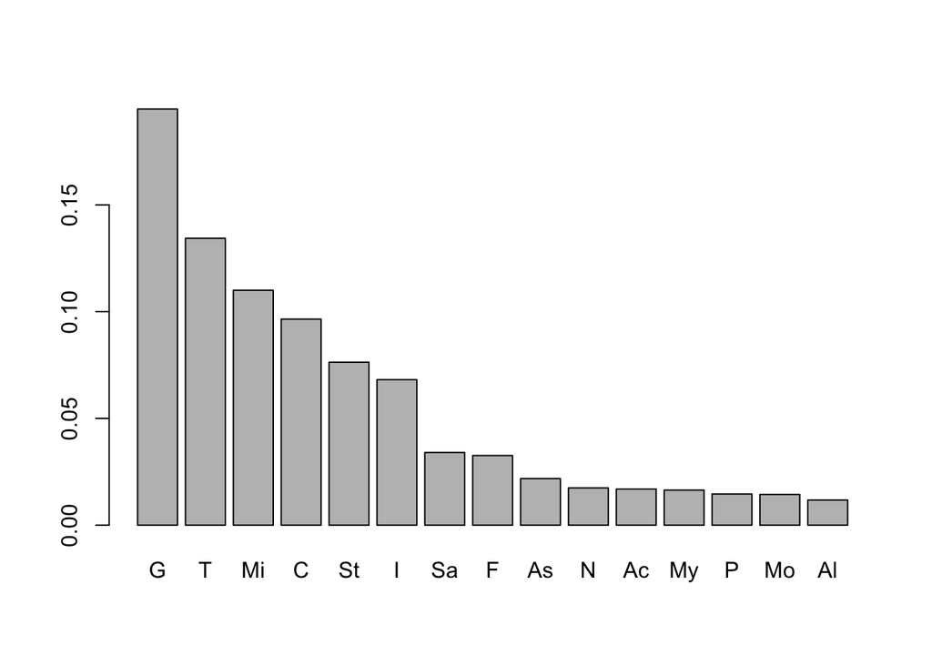

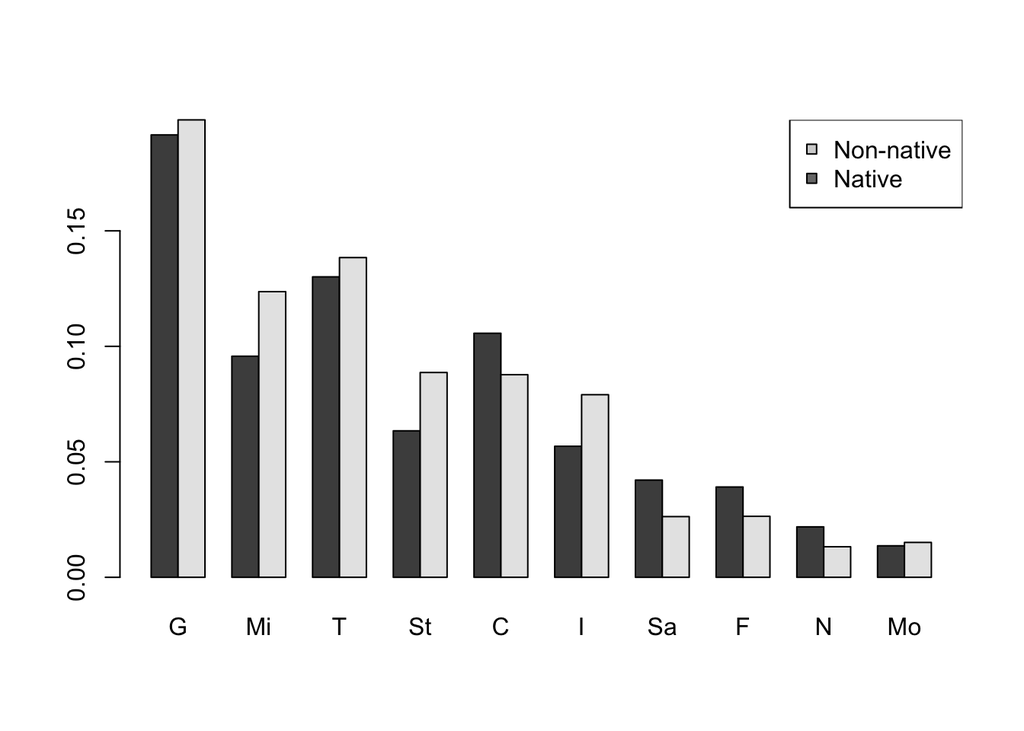

### By Function

I ran my taxonomy data through the FUNGuild database to get functional guilds for all taxa. Unclassified taxa were obviously not matched. FUNGuild gives trophic mode and Guild as outputs. Guild is nested within trophic mode, so I have shown the data by trophic mode, then guild

#### Trophic Mode

I created a plot of relative abundance by trophic mode

```
##                        Pathotroph                        Saprotroph
##                       0.481503782                       0.329748387
##            Pathotroph-Symbiotroph             Pathotroph-Saprotroph
##                       0.086647847                       0.083121403
##                       Symbiotroph Pathotroph-Saprotroph-Symbiotroph
##                       0.017543839                       0.001434742
```

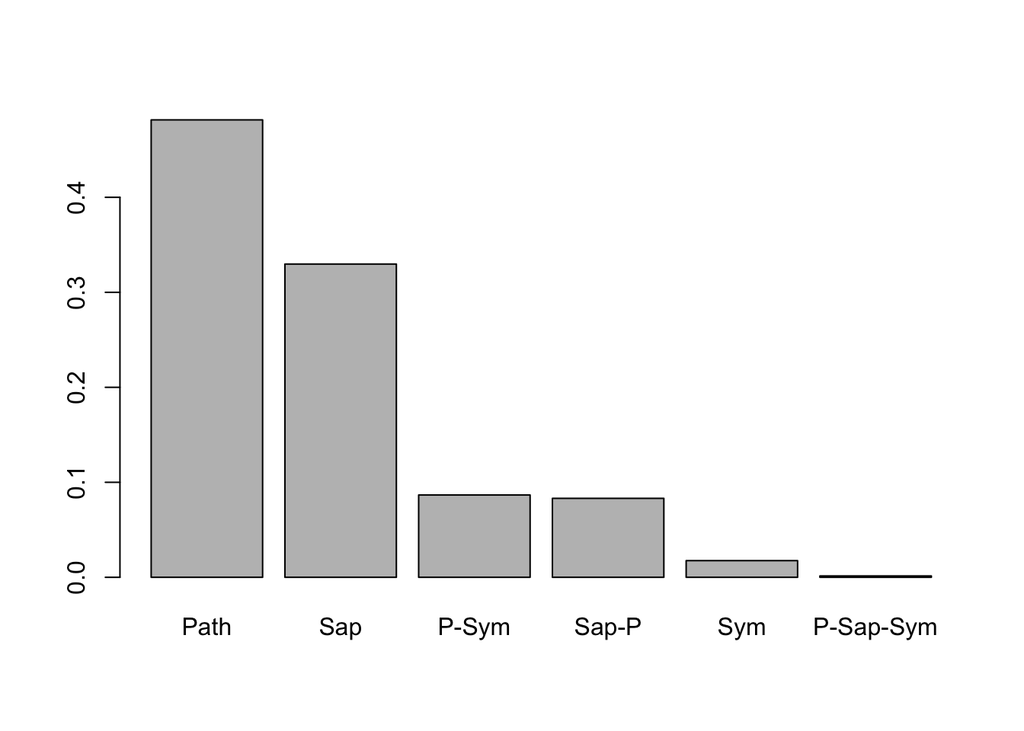

Pathogens are most abundant. The pathotroph-symbiotroph category is difficult to know what to do with. I assume they have been shown to have multiple trophic modes depending on the host.

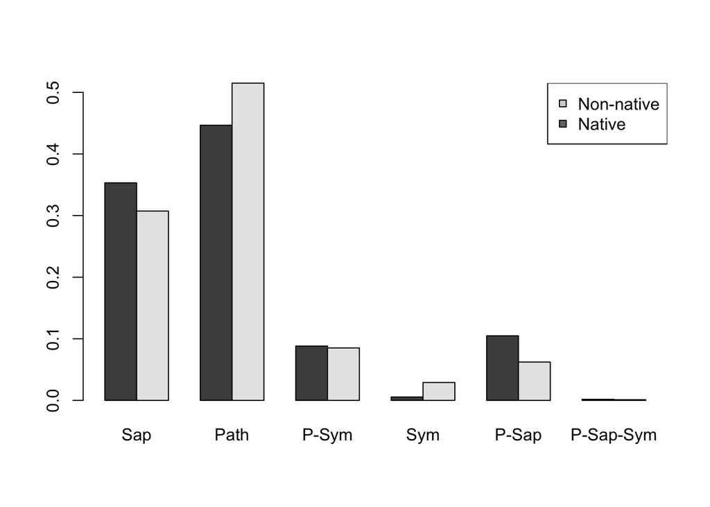

##### Community by Trophic mode

Here is a community analysis by trophic mode. First I ran a Permanova to see if the sites had significatly different communities of trophic modes.

```
##
## Call:
## adonis(formula = trophic_shared ~ Site * Lineage, data = meta_alpha)
##
## Permutation: free
## Number of permutations: 999
##
## Terms added sequentially (first to last)
##
##              Df SumsOfSqs  MeanSqs F.Model      R2 Pr(>F)
## Site          7    1.0792 0.154175  2.3043 0.27262  0.011 *
## Lineage       1    0.0761 0.076057  1.1367 0.01921  0.338
## Site:Lineage  7    0.7293 0.104186  1.5571 0.18422  0.090 .
## Residuals    31    2.0742 0.066909         0.52395
## Total        46    3.9588                  1.00000
## ---
## Signif. codes:  0 '***' 0.001 '**' 0.01 '*' 0.05 '.' 0.1 ' ' 1
```

Here is an NMDS grouped by trophic mode (stress = 0.1925223)

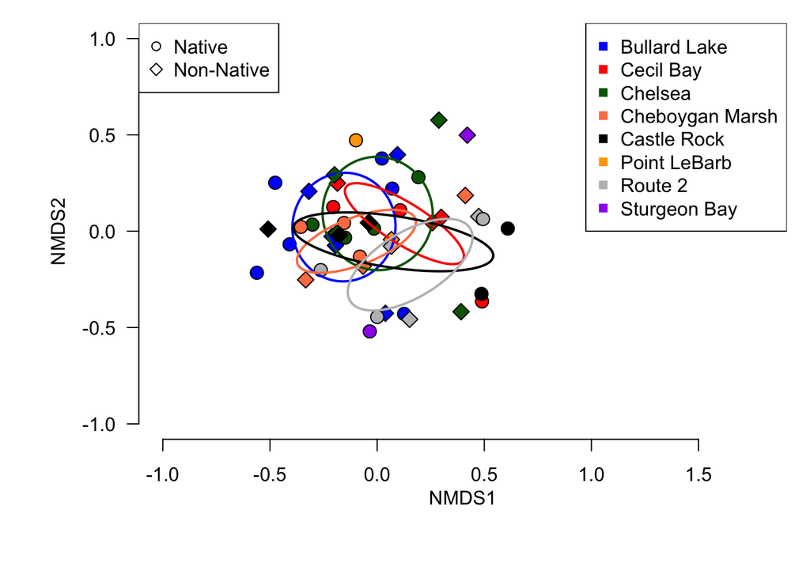

I performed Kruskel-Wallace tests to see if any individual trophic modes were significantly different by site. None were.

#### Guild

Here are the top 10 functional guilds by relative abundance. The bar plot is numbered by the most abundant to least. Refer to the list for guild names

```
##                                 Plant Pathogen
##                                    0.372692066
##                           Undefined Saprotroph
##                                    0.299353453
##                       Plant Pathogen-Endophyte
##                                    0.105820305
##                            Undefined Endophyte
##                                    0.086720047
## Plant Pathogen-Soil Saprotroph-Wood Saprotroph
##                                    0.031155827
##                     Animal Pathogen-Saprotroph
##                                    0.029032564
##                                Dung Saprotroph
##                                    0.021105054
##                                Ectomycorrhizal
##                                    0.014495417
##                 Plant Pathogen-Wood Saprotroph
##                                    0.014218544
##           Dung Saprotroph-Undefined Saprotroph
##                                    0.005794305
```

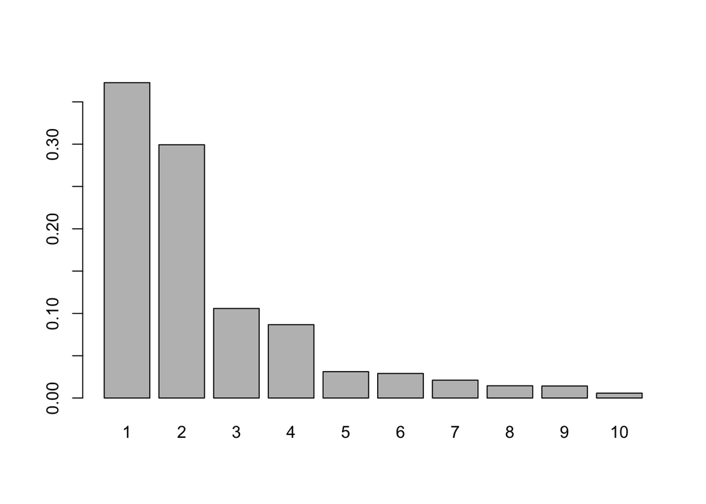

```
##
## Call:
## adonis(formula = all_guild_shared ~ Site * Lineage, data = meta_alpha)
##
## Permutation: free
## Number of permutations: 999
##
## Terms added sequentially (first to last)
##
##              Df SumsOfSqs  MeanSqs F.Model      R2 Pr(>F)
## Site          7    1.5759 0.225133 2.01855 0.25643  0.005 **
## Lineage       1    0.0483 0.048297 0.43303 0.00786  0.797
## Site:Lineage  7    1.0640 0.151996 1.36280 0.17312  0.123
## Residuals    31    3.4575 0.111532         0.56259
## Total        46    6.1457                  1.00000
## ---
## Signif. codes:  0 '***' 0.001 '**' 0.01 '*' 0.05 '.' 0.1 ' ' 1
```

The permanova by functional guild still shows significant difference by site

I performed Kruskel-Wallace tests to see if any individual guilds were significantly different by site. None were.

plot NMDS scores against nitrogen content

```
##
## Call:
## lm(formula = ma_finite$SoilN ~ NMDS1 * NMDS2)
##
## Coefficients:
## (Intercept)        NMDS1        NMDS2  NMDS1:NMDS2
##      0.5824      -0.5598      -0.4223      -0.9339
```

```
##
## Call:
## lm(formula = ma_finite$SoilN ~ NMDS1 * NMDS2)
##
## Residuals:
##     Min      1Q  Median      3Q     Max
## -0.8347 -0.4675 -0.1388  0.1189  2.1371
##
## Coefficients:
##             Estimate Std. Error t value Pr(>|t|)
## (Intercept)   0.5824     0.1204   4.837 2.98e-05 ***
## NMDS1        -0.5598     0.3921  -1.428    0.163
## NMDS2        -0.4223     0.4633  -0.912    0.369
## NMDS1:NMDS2  -0.9339     1.7862  -0.523    0.605
## ---
## Signif. codes:  0 '***' 0.001 '**' 0.01 '*' 0.05 '.' 0.1 ' ' 1
##
## Residual standard error: 0.7092 on 33 degrees of freedom
## Multiple R-squared:  0.1007, Adjusted R-squared:  0.01891
## F-statistic: 1.231 on 3 and 33 DF,  p-value: 0.3139
```

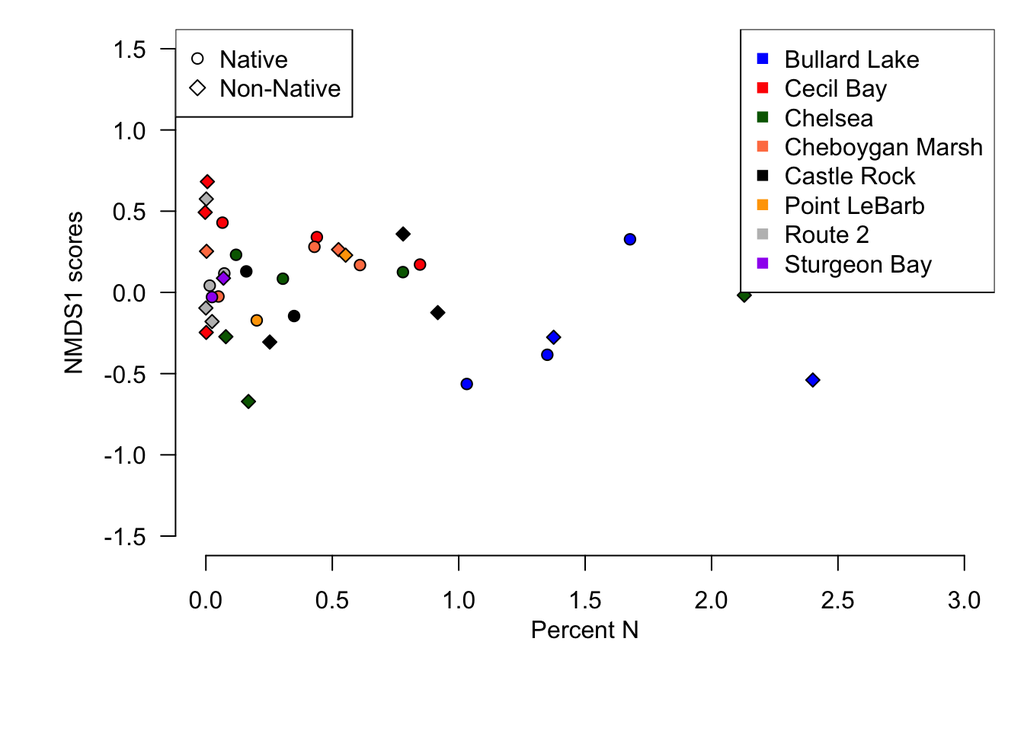

Now plot against P

```
##
## Call:
## lm(formula = ma_finite$SoilP ~ NMDS2 * NMDS1)
##
## Coefficients:
## (Intercept)        NMDS2        NMDS1  NMDS2:NMDS1
##       3.031       11.449       -2.728      -39.605
```

```
##
## Call:
## lm(formula = ma_finite$SoilP ~ NMDS2 * NMDS1)
##
## Residuals:
##     Min      1Q  Median      3Q     Max
## -12.715  -2.505  -1.298   0.469  41.159
##
## Coefficients:
##             Estimate Std. Error t value Pr(>|t|)
## (Intercept)    3.031      1.453   2.086   0.0448 *
## NMDS2         11.449      5.589   2.048   0.0486 *
## NMDS1         -2.728      4.732  -0.577   0.5682
## NMDS2:NMDS1  -39.605     21.552  -1.838   0.0751 .
## ---
## Signif. codes:  0 '***' 0.001 '**' 0.01 '*' 0.05 '.' 0.1 ' ' 1
##
## Residual standard error: 8.557 on 33 degrees of freedom
## Multiple R-squared:  0.1959, Adjusted R-squared:  0.1228
## F-statistic:  2.68 on 3 and 33 DF,  p-value: 0.06288
```

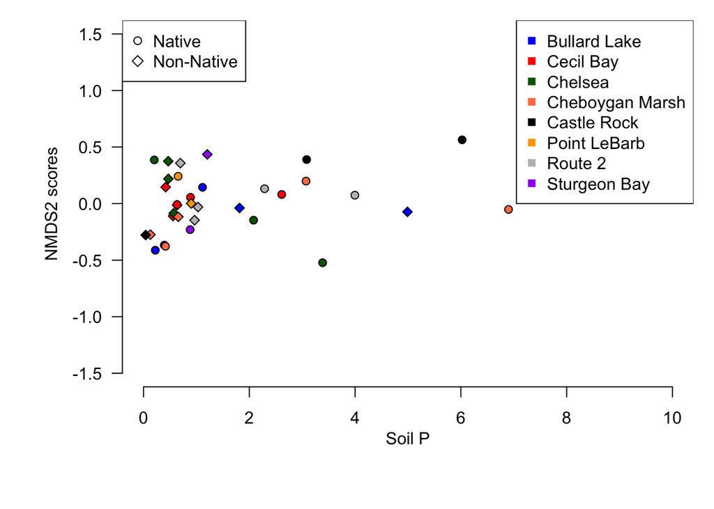

Adding nutrients into PerMANOVA

```
##
## Call:
## adonis(formula = shared_finite ~ SoilN + SoilP, data = ma_finite,      method = "bray")
##
## Permutation: free
## Number of permutations: 999
##
## Terms added sequentially (first to last)
##
##           Df SumsOfSqs MeanSqs F.Model      R2 Pr(>F)
## SoilN      1    0.4353 0.43532 1.34013 0.03692  0.135
## SoilP      1    0.3116 0.31158 0.95921 0.02643  0.505
## Residuals 34   11.0442 0.32483         0.93666
## Total     36   11.7911                 1.00000
```